# Intro to metabolomics concepts

From colon-model samples to a data matrix

Author

Anna Mascellani Bergo, Czech University of Life Sciences Prague, Prague

These teaching materials were developed drawing on contributions from Dr. Jaroslav Havlik and Dr. Saetbyeol Lee, Czech University of Life Sciences Prague.

# 1 Session overview

**Central question**

> How do samples from a colon model become a metabolomics data matrix, and what must we check before interpreting it?

This 70-minute session introduces metabolomics data to participants with little or no previous experience. It follows the complete journey from an *in vitro* colon model sample to a processed data table and uses a small, real colon-model dataset as an accessible example.

This document is the reading companion to the lecture. It brings together the concepts from the slides, explains their connections, and finishes with an R demonstration that you can revisit at home.

## 1.1 Learning outcomes

By the end of the session, you should be able to:

1. Explain what metabolomics measures and how it complements microbiome sequencing.
2. Distinguish targeted, semi-targeted and untargeted metabolomics.
3. Recognise the main analytical platforms and the types of signals they generate.
4. Describe how analytical signals are converted into a processed data matrix.
5. Recognise metadata, measurement and annotation tables.
6. Identify essential checks required before biological interpretation.

**The guiding principle**

Start with the biological question, design the required evidence, protect its quality, and only then build the story.

# 2 Why is the workflow important?

The quality of a biological conclusion depends on the whole workflow. A sophisticated instrument cannot recover information lost through poor sampling, degradation, an unsuitable extraction, or an experimental design that confounds treatment with processing batch. Quality must be protected from collection through storage, preparation, acquisition, processing and interpretation. A numerical table is the outcome of these decisions, rather than an independent description of biology.

# 3 What is metabolomics?

**Metabolomics is the systematic measurement of metabolites in biological samples.** Metabolites are small molecules, often below approximately 1,000 Da, that participate in or result from biochemical reactions.

Metabolites can originate from the experimental substrate, microbial metabolism, host metabolism, or interactions among these sources. In a colon-model experiment, a compound may already be present in the medium, substrate or inoculum before fermentation starts. Its detection after incubation does not automatically establish that it was newly produced by the microorganisms.

Metabolomics is close to the observable phenotype because metabolite concentrations can change with microbial activity, diet, environmental conditions and experimental treatment. It therefore helps us describe the **chemical state of a sample at the time of measurement**.

# 4 What information does a colon model produce?

A colon-model experiment can generate several complementary layers of data.

| Data layer | Examples | What it helps us understand |
| --- | --- | --- |
| Experimental metadata | Treatment, concentration, incubation time, donor, vessel and replicate | What was done, to which sample, and under which conditions |
| Microbiome data | Taxa, genes and metabolic pathways | Community composition and functional potential |
| Metabolite data | Substrates remaining and fermentation products | The measured chemical phenotype |
| Phenotypic or functional measurements | Measurements selected for the experimental question | Functional outcomes and the context of the other data layers |

These layers become useful together only when their sample identifiers and experimental context can be matched correctly.

## 4.1 Why measure metabolites if we know which microorganisms are present?

**Presence does not mean activity.** A microorganism may be present but metabolically inactive under the conditions being studied.

**Potential does not confirm production.** Genes associated with butyrate production indicate a capacity for that process. Measuring butyrate provides evidence about its concentration and, with appropriate baseline measurements and controls, its accumulation.

**Similar communities can behave differently.** Differences in substrate availability, microbial interactions or environmental conditions can produce different metabolite profiles even when community composition appears similar.

## 4.2 Functional potential versus observed phenotype

| Microbiome sequencing | Metabolomics |
| --- | --- |
| Which microorganisms and genes are present? | Which small molecules are present? |
| What could the community potentially do? | What chemical phenotype is observed? |
| Describes composition and, depending on the sequencing approach, functional potential | Describes the measured metabolic phenotype |

The presence of a species or a metabolic gene does not prove that a pathway was active. Equally, the presence of a metabolite does not identify the organism that produced it. Taxonomic profiling and direct measurement of genes also provide different levels of evidence about functional potential.

**Concentration is not a direct measurement of flux**

A concentration reflects the balance of inputs, production, consumption and losses up to the sampling time. A compound can be produced and then consumed by another organism. A low final concentration therefore does not necessarily mean low production.

# 5 Different metabolic routes can lead to the same compound

Adding metabolomics does not remove every ambiguity. Several organisms or pathways can contribute to the same compound, and microorganisms can use products released by other community members. This exchange is often called **cross-feeding**.

## 5.1 Example 1: increased butyrate, propionate and total SCFAs

Suppose an experimental condition shows higher butyrate, propionate and total short-chain fatty acids (SCFAs) than the control. The direct observation is higher measured concentrations of these products under that condition. This could be caused by different species such as *Ruminococcus*, *Bifidobacterium*, *Roseburia*, *Faecalibacterium* and *Eubacterium/Anaerobutyricum*. This is not a one-to-one assignment of each organism to each measured acid: organisms may contribute directly or through the substrates they provide to others.

The observed pattern alone cannot tell us which organism produced a compound, which route dominated, or whether the difference reflects increased production, reduced consumption, or both. Interpretation needs the substrate, incubation time, baseline, controls and other available data.

**Total SCFA also needs a definition.** Record which compounds were included and their units. The six organic acids in the demonstration are not interchangeable with a standard “total SCFA” measurement; do not simply sum all six and label the result total SCFA.

## 5.2 Example 2: aromatic amino acids and fermentation products

The second example connects phenylalanine (Phe), tyrosine (Tyr) and tryptophan (Trp) with products such as phenylacetate, phenylpropionate, *p*-cresol and indole. *Clostridium* species, *Peptostreptococcus* species, *Bacteroides* species and *Escherichia coli*/Enterobacteriaceae are examples relevant to these transformations.

Again, a metabolite is not a unique label for a taxon or a pathway. A pattern involving substrates and several products is more informative than an isolated change, especially when interpreted alongside the experimental conditions.

## 5.3 Saccharolytic and proteolytic fermentation profiles

**The overall metabolic picture can often be interpreted in relation to broad metabolic processes. For in vitro gut models, one example is the balance between saccharolytic and proteolytic fermentation profiles.**

**Saccharolytic fermentation** involves microbial use of carbohydrates and can generate organic acids, including SCFAs, and gases. **Proteolysis** breaks proteins into peptides and amino acids; subsequent amino-acid metabolism can generate a range of fermentation products, among them branched-chain fatty acids (BCFA), phenols and indoles.

| Broad process | Substrates considered | Examples of associated measurements in the lecture |
| --- | --- | --- |
| Saccharolytic fermentation | Carbohydrates | Lactate, acetate, propionate, butyrate and gases |
| Proteolytic fermentation and amino-acid metabolism | Proteins, peptides and amino acids | Branched-chain fatty acids, ammonia, amines, phenolic compounds, indole-related compounds and sulfides |

These are broad profiles, not mutually exclusive categories. SCFAs can occur in more than one metabolic context, and the two types of metabolism can coexist in a community.

**Important**

Instead of assigning a pathway from one metabolite, look for a pattern across several metabolites and consider the experimental context.

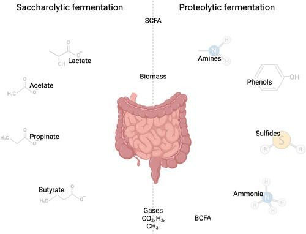

Figure 1: Saccharolytic and proteolytic fermentation profiles share some outcomes. Figure reproduced from Boven et al. (2024), DOI 10.1080/10408398.2024.2352523.

# 6 From the biological question to the analytical strategy

The interpretation problem leads directly to a practical question: **what should we measure?**

If we already know which compounds are needed to answer our question, a focused assay may be appropriate. If we need to explore a wider response, broader profiling may be useful. The strategy determines which part of the sample’s chemistry will be visible.

## 6.1 Targeted, semi-targeted and untargeted approaches

| Strategy | Main purpose | What is measured | Main consideration |
| --- | --- | --- | --- |
| Targeted | Test a focused question | Specific, predefined metabolites | Optimise and validate measurement of the chosen compounds |
| Semi-targeted | Combine a defined focus with some exploration | A selected set of known metabolites, sometimes alongside additional signals | State what the method actually covers; usage of this term varies |
| Untargeted | Explore a broad chemical response | Many detectable features within the method’s analytical window | Many features may remain unidentified or only provisionally annotated |

Targeted assays can offer high sensitivity and reliable quantification for the selected compounds. Untargeted profiling expands the search space, but a detected feature is not necessarily a distinct, identified metabolite.

## 6.2 Can one method measure everything?

**No single method sees it all.** Metabolites differ in polarity, volatility, solubility, molecular structure and concentration. Sample preparation and instrument settings further define what can be detected.

“Untargeted” therefore means broad exploration within an analytical window, not complete measurement of every compound in a sample. Complementary methods can expand coverage.

# 7 Choosing the analytical platform

The lecture introduces proton nuclear magnetic resonance spectroscopy (¹H NMR), liquid chromatography–mass spectrometry (LC–MS) and gas chromatography–mass spectrometry (GC–MS). The practical demonstration uses targeted high-performance liquid chromatography (HPLC).

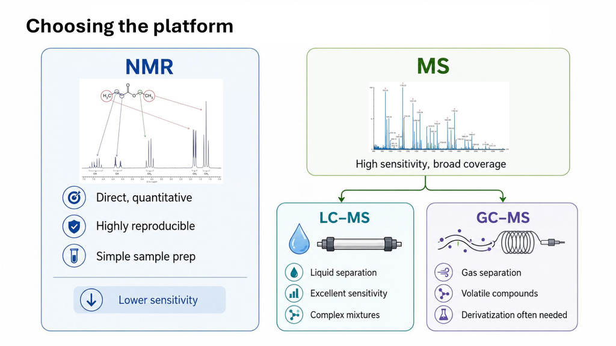

Figure 2: Key analytical peculiarities of the most commonly used techniques in metabolomics.

## 7.1 What each platform measures

**¹H NMR** records signals from hydrogen nuclei in different chemical environments. Spectra show signal intensity against chemical shift, expressed in parts per million (ppm). Signal positions, splitting patterns and integrals help with assignment and quantification.

**LC–MS** separates compounds by liquid chromatography and detects ions by mass spectrometry. A signal is described by retention time, mass-to-charge ratio (*m/z*) and intensity. Fragmentation spectra (MS/MS), where available, add structural information.

**GC–MS** separates volatile compounds, or compounds made suitable for analysis through derivatisation, before mass-spectrometric detection. Retention behaviour and fragmentation patterns support identification.

**HPLC** is a separation method and is not synonymous with LC–MS. An HPLC assay can use another detector. In a targeted organic-acid assay, calibrated chromatographic peak responses can be converted into a table of compound measurements. The detector and calibration details must come from the method documentation.

## 7.2 Platform comparison

The following summarises the teaching comparison in the slides. Sensitivity and coverage depend strongly on the sample, preparation, instrument and method; the numerical ranges are illustrative, not guaranteed performance specifications.

| Aspect | ¹H NMR | LC–MS | GC–MS |
| --- | --- | --- | --- |
| Indicative sensitivity in the slides | Often µM for routine profiling | Can reach nM–pM for suitable analytes and methods | Can reach nM for suitable volatile or derivatised compounds |
| Illustrative metabolite coverage in the slides | 30–80 | 200 to more than 1,000 | 100–500 |
| Quantification | Signal integrals can be quantitative under appropriate acquisition and referencing conditions | Usually needs appropriate standards and calibration for absolute concentrations | Usually needs appropriate standards and calibration for absolute concentrations |
| Sample preparation | Often relatively simple and fast | Method-dependent; often moderately complex | Can be more complex, particularly when derivatisation is required |
| Reproducibility and matrix effects | Often highly reproducible; acquisition conditions and matrix-related spectral changes still matter | Matrix effects and instrumental drift require careful control | Can be highly reproducible when standardised; derivatisation may introduce variation |
| Structural information | Chemical shifts and coupling patterns support assignment; overlap can limit interpretation | MS/MS supports annotation; isomer discrimination can be difficult | Fragmentation patterns and spectral libraries can strongly support identification |

# 8 Sample preparation and acquisition

The sample journey follows five stages: **collection, storage, preparation, acquisition and raw data**. Decisions at every stage affect the final matrix.

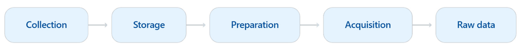

Figure 3: The sample journey: collection, storage, preparation, acquisition and raw data.

## 8.1 Design, randomisation and confounding

Plan the experiment around the question and the comparisons needed to answer it. Consider sample size and power before collecting data, and distinguish **biological replicates** from **technical replicates**.

Biological replicates represent independent biological or experimental units at the level relevant to the question. Technical replicates repeat a measurement or processing step on the same underlying material. Repeated injections do not create additional independent biological samples.

Randomise preparation and acquisition where appropriate, and distribute conditions across batches. Record potential confounding factors. If every control is measured in one batch and every treatment in another, a treatment difference may be indistinguishable from a batch effect.

## 8.2 Collection and storage

Record collection time, location, preservation method, storage conditions and relevant handling steps. Snap freezing can be part of a validated protocol, but the preservation approach should suit the sample and intended measurements.

Light, temperature, microorganisms and enzymes can alter samples after collection. Metabolites do not all degrade at the same rate, so inconsistent handling may change composition as well as overall abundance.

The practical message from the slides is to ask **how the sampling was performed**, rather than only whether someone followed the protocol. Detailed records reveal deviations that a yes/no answer can miss.

## 8.3 Extraction and measurement

An extraction must recover the compounds relevant to the question. Optimisation may be needed, and a protocol that works for one chemical class may not work for another.

Record extraction batches, acquisition batches, internal standards, quality-control samples, run order and any deviations from the protocol. Continue to consider degradation during preparation and time spent awaiting measurement.

| Quality-related material or record | What it helps assess |
| --- | --- |
| Blank | Background signals and contamination introduced by reagents or processing |
| Quality-control sample (QC) | Analytical consistency, repeatability and drift |
| Internal standard | Aspects of preparation or measurement performance, depending on when and how it is added |
| Batch and run-order metadata | Whether technical patterns overlap with experimental conditions |

QCs are particularly important for following LC–MS performance over a run. They do not replace independent biological replication.

# 9 What does raw data look like?

Raw instrument output is not yet the table used for statistics.

| Platform | Raw-data representation | Processing needed before a measurement table |
| --- | --- | --- |
| LC–MS | Signals distributed across retention time, *m/z* and intensity | Peak detection, integration, alignment and feature correspondence across samples |
| GC–MS | Chromatographic peaks with associated mass spectra | Peak detection, separation of overlapping contributions where needed, integration and alignment |
| NMR | Spectra with signal intensity against chemical shift | Spectral processing, referencing, appropriate alignment and integration, binning or compound fitting |
| Targeted HPLC | Chromatographic detector responses | Peak assignment, integration and calibration for the chosen acids |

# 10 From analytical signals to a data matrix

For a **targeted workflow**, predefined compounds guide signal assignment and integration. QC inspection and quality filtering establish which measurements are usable. Appropriate normalisation, if needed, precedes statistical analysis and biological interpretation.

For an **untargeted workflow**, processing first creates features. QC inspection, blank assessment and quality filtering remove unreliable or background signals. Further filtering and any justified normalisation prepare the matrix for analysis. Annotation may occur at several stages and may be revisited when interpreting features of interest.

These steps are iterative: an unexpected result may lead us back to the chromatogram or spectrum. Do not treat a processed matrix as unquestionable simply because software exported it.

## 10.1 The three linked tables

A usable metabolomics dataset normally needs three linked components.

| Table | One row represents | Typical columns | Link to the other tables |
| --- | --- | --- | --- |
| Sample metadata | A sample | Sample ID, condition, donor, time point, replicate, batch and run order | Sample ID |
| Measurement matrix | A sample in the usual samples-by-variables layout | Sample ID and metabolite or feature measurements | Sample ID and feature/compound identifiers |
| Annotation table | A feature or compound | Feature ID, proposed identity, retention time, *m/z*, unit and identification confidence, as applicable | Feature/compound identifier |

In a small targeted CSV, metadata and measurements may be stored together. Conceptually, they still have different roles. A treatment label is not a metabolite, and a replicate number should not accidentally enter a numerical metabolite matrix.

Sample identifiers should be unique at the intended row level and should match across tables. The annotation table explains what each numerical variable means; the metadata explains the sample and comparison it belongs to.

## 10.2 Features and annotation confidence

A **feature** is a reproducible analytical signal. Several features can originate from one compound, and overlapping compounds can contribute to a signal. Feature counts are therefore not necessarily metabolite counts.

According to the Metabolomics Standards Initiative (MSI) (Sumner et al. (2007), DOI: 10.1007/s11306-007-0082-2), confidence levels are attributed as follows:

| Level | Description | Evidence represented |
| --- | --- | --- |
| 1 | Identified compound | Confirmation against an authentic standard using at least two independent, orthogonal properties measured under identical conditions |
| 2 | Putatively annotated compound | Assignment from physicochemical properties or spectral/library evidence without the level-1 standard confirmation |
| 3 | Putatively characterised compound class | Evidence supports a chemical class rather than a specific compound identity |
| 4 | Unknown compound | A distinguishable analytical signal without an assigned chemical identity |

Carry annotation confidence into interpretation. A tentative name should not silently become a confirmed compound in a pathway claim.

## 10.3 Missing values and filtering

The slides show that an untargeted table can contain up to 20,000 features or more, with missing entries and variables that need filtering. A missing value is not automatically a biological zero. It can reflect a signal below the detection limit, a processing failure, interference or another measurement problem.

Before deciding how to handle missing values, ask whether they cluster by feature, condition, batch or run order. Inspect blank responses and QC performance where these are available. Document the criteria used to remove features or samples, and avoid applying an unexplained universal threshold.

Filling in missing values can be appropriate for some analyses, but it requires an explicit assumption about why values are missing. It cannot repair a fundamentally inadequate measurement.

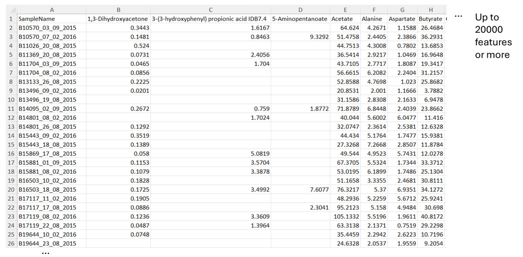

Figure 4: An example feature table before filtering. Large untargeted tables can contain many thousands of features.

# 11 Normalisation: making samples comparable

The slides introduce **sample-wise normalisation** as a row operation. One factor rescales all variables in a sample to account for a difference such as dilution or the amount of material measured.

For a measurement matrix with samples in rows, a simple representation is:

$$x^{\mathrm{normalised}}_{ij}=\frac{x_{ij}}{s_i},$$

where $x_{ij}$ is the measurement for variable $j$ in sample $i$ and $s_i$ is that sample’s normalisation factor.

For example, consider two aliquots of the same in vitro colon-model fermentation supernatant. If one is diluted twofold and the other fourfold before analysis, the more diluted aliquot will show lower measured concentrations even though both originated from the same biological sample. Multiplying the measured concentrations by their respective dilution factors restores them to the original-supernatant basis, making them comparable. This corrects a known sample-preparation difference; it does not remove genuine differences in metabolite accumulation between experimental conditions.

**Is normalisation always needed? No.** The decision depends on the experimental design, measurement units and scientific question. In a colon model, a change in total metabolite concentration may itself be an outcome of interest. Forcing samples to have equal totals could remove that information.

Sample-wise normalisation is also different from transformation or variable-wise scaling. These operations answer different statistical needs and should be documented separately. No processing step guarantees that every remaining difference is biological.

# 12 The reality check before interpretation

Following the “reality check” from Limonciel’s book *The STORY Principle*, we establish whether the data are fit for the question before building a biological explanation.

| Dimension | Questions to ask |
| --- | --- |
| Data structure | Does the design contain the needed comparison? Are samples independent, paired or repeated? Do IDs and metadata match? |
| Data quality | Are measurements reliable? Are missingness, blanks, QC behaviour, drift and batch effects acceptable for the intended analysis? |
| Data quantity | Are there enough independent observations and sufficient analytical coverage to support the proposed conclusion? |
| Fitness for purpose | Which questions can this dataset answer, and which remain beyond it? |

A visible difference is a starting observation. Its interpretation depends on measurement reliability, within-condition variability, experimental independence and adequate replication. Descriptive exploration and statistically supported treatment effects are different levels of evidence.

# 13 Demo: exploring a targeted organic-acid dataset

## 13.1 Study context and teaching subset

This example comes from Garcia-Gutierrez et al. (2026), *A microbiota-informed pipeline for in vitro characterisation of insulinotropic properties of dairy fermentates using static EndoC-βH1 and dynamic microfluidic models*, **Food Research International**, 242, 120207. DOI: 10.1016/j.foodres.2026.120207.

The study digested six dairy fermentates using the INFOGEST protocol, then incubated them with a **pooled faecal inoculum in a microMatrix colon model**. Fermentates were added at 1% and 5% (w/v), in duplicate wells, and incubated for 24 hours at 37 °C with pH maintained at 6.8. Unfed control wells contained diluted faecal slurry without added fermentate (Methods 2.2).

The study combined shallow whole-genome shotgun sequencing (WGS) with targeted HPLC measurements of six organic acids. Cell-free colonic fermentation supernatants were then tested for their effects on **insulin secretion by human EndoC-βH1 cells** in three independent experiments. A separate dynamic microfluidic assay used mouse pancreatic islets. Insulin was measured in these downstream cell assays, not produced or measured as a microbial metabolite in the colon-model wells.

The teaching subset selection and sample renaming described below were supplied with the CSV files.

The original data collection contained 26 samples. For this introductory exercise, it was reduced to six samples by retaining:

- Two fermentates, **Ferm1 and Ferm4**, selected for a complete teaching comparison. Both were included in the paper’s dynamic assay, which also included Ferm6.
- The **5% concentration** for the two fermentates.
- The **T24 unfed control**, rather than the initial T0 control.
- Two replicates per condition, renamed **Control_R1/R2, A_R1/R2 and B_R1/R2**.

For clearer interpretation, the teaching labels use the paper’s fermentate numbers and composition:

| CSV label | Label used in this demo | Protein | Lactose |
| --- | --- | --- | --- |
| Control | Unfed T24 control | — | — |
| A | Ferm1: moderate protein, higher lactose | 56% | 30% |
| B | Ferm4: high protein, low lactose | 90% | 0.8% |

Composition refers to the dairy ingredients before digestion (paper, Table 1), not to final concentrations in the fermentation wells. The working mapping A → Ferm1 and B → Ferm4 follows the selected products and their matching organic-acid profiles in Figure 3; the CSV itself does not encode the original product key. The code retains the supplied sample IDs and uses the clearer names for comparisons and plot labels.

**Targeted HPLC measurement of six organic acids**

| Samples | Conditions | Treatment concentration | Control | Replication | Variables |
| --- | --- | --- | --- | --- | --- |
| 6 | Control, Ferm1, Ferm4 | 5% for Ferm1 and Ferm4 | Unfed, T24 | 2 per condition | 6 organic acids |

Subsetting and renaming preserve the measurements. All six acids, all three insulin experiments, and all 190 species with their taxonomy are retained for these six samples.

| File in `data/` | Contents | Layout |
| --- | --- | --- |
| `acids.csv` | Six organic acids: formic, acetic, propionic, lactic, butyric and citric | 6 sample rows; identifiers and acids in columns |
| `insulin.csv` | Insulin measurements from three experiments | 18 rows; each sample occurs in experiments 1, 2 and 3 |
| `abundance.csv` | Microbiome abundance values for 190 species | Species in rows; the six samples in columns |
| `taxonomy.csv` | Taxonomic assignments for the 190 species | Species, kingdom, phylum, class, order, family and genus |

The demonstration uses **`acids.csv`**. The other files provide opportunities to connect data layers later; they are not required to run the organic-acid code below.

**Measurement information**

The paper describes **duplicate fermentation wells prepared from a pooled faecal standard** (Methods 2.2.2). These are not two independent donors. The microbiome methods call the pairs technical replicates, while the Discussion describes the SCFA replication as biological (n = 2). For this exercise, the concrete description “duplicate fermentation wells” is more useful than assuming donor-level independence. Replicate labels do not establish pairing between conditions.

The HPLC methods report concentrations in **µg/mL**, subsequently converted to **mM** using each acid’s molecular weight (Methods 2.3.3; Figure 3). All acid concentrations and concentration differences in this example are expressed in **mM**.

## 13.2 What can this small dataset tell us?

The small design is useful for learning to inspect individual measurements, reshape tables and describe patterns. Limited replication is a common practical issue in in vitro work and provides a useful opportunity to discuss the boundary between exploration and inference.

With two observations per condition, show both points rather than hiding them behind a group mean. We can compare observed values, calculate differences and generate hypotheses. Estimating variability precisely, assessing assumptions and generalising beyond this experiment require stronger support.

A formal test is not ruled out simply because there are two observations. Its validity depends on the experimental unit, independence, design and assumptions, and its information and power may be very limited. Treating technical repeats as independent biological samples would overstate replication. This demo therefore uses **descriptive summaries without p-values or claims of significant treatment effects**.

## 13.3 Running the demonstration at home

After downloading or cloning the repository, keep the arrangement on your computer. The demo reads `data/acids.csv`. In R, use the repository folder as the working directory so that the `data/` folder is available at this relative path.

The file should contain the columns `sample`, `product`, `replicate`, `formic`, `acetic`, `propionic`, `lactic`, `butyric` and `citric`. Product labels for the selected rows should be `Control`, `A` and `B`, and sample labels should match the six listed above. The acid columns must be numeric.

Use R with the packages `knitr` and `tidyverse`. If needed, install them once in the R console:

```r
# Install these packages once; this requires an internet connection.
install.packages(c("knitr", "tidyverse"))
```

## 13.4 Import and inspect the teaching subset

Before plotting, identify the sample identifier, experimental variables and metabolite columns. This code selects the six teaching samples and converts the supplied mass concentrations to mM by dividing each acid column by its molecular weight. The CSV remains unchanged. All subsequent summaries and plots use the converted values.

```r
# Load the functions for reading, reshaping, summarising and plotting data.
library(tidyverse)

# Read the CSV as a table; hide the column-type message.
acids <- read_csv(data_file, show_col_types = FALSE)

# Create a character vector containing the six measurement-column names.
acid_names <- c(
  "formic", "acetic", "propionic",
  "lactic", "butyric", "citric"
)
# List the sample IDs to retain for the teaching subset.
teaching_samples <- c(
  "Control_R1", "Control_R2",
  "A_R1", "A_R2",
  "B_R1", "B_R2"
)
# Combine the metadata and measurement names expected in the file.
required_columns <- c("sample", "product", "replicate", acid_names)
# Find required names that are absent from the imported table.
missing_columns <- setdiff(required_columns, names(acids))
# Stop if any required columns are missing.
if (length(missing_columns) > 0) {
  # Stop execution and show a message so the input can be corrected.
  stop("Missing columns: ", paste(missing_columns, collapse = ", "))
}

# Pass acids to the next operation with |> and save the result back to acids.
acids <- acids |>
  # Keep rows whose sample ID belongs to the teaching-sample list.
  filter(sample %in% teaching_samples)

# Check for six rows, unique IDs, and exactly the intended set of samples.
if (nrow(acids) != 6L || anyDuplicated(acids$sample) > 0L ||
    !setequal(acids$sample, teaching_samples)) {
  # Stop execution and show a message so the input can be corrected.
  stop("Expected exactly one row for each of the six teaching sample IDs.")
}
# Remove the final _R1 or _R2 from each ID to obtain its expected product label.
expected_product <- sub("_R[12]$", "", acids$sample)
# Check that product labels are present and agree with the sample IDs.
if (anyNA(acids$product) || any(acids$product != expected_product)) {
  # Stop execution and show a message so the input can be corrected.
  stop("Product labels do not agree with the teaching sample IDs.")
}
# Apply is.numeric to each acid column; all six results must be TRUE.
if (!all(vapply(acids[acid_names], is.numeric, logical(1)))) {
  # Stop execution and show a message so the input can be corrected.
  stop("All six organic-acid columns must contain numeric measurements.")
}
# Check each measurement column for invalid infinite values.
if (any(vapply(acids[acid_names], function(x) any(is.infinite(x)), logical(1)))) {
  # Stop execution and show a message so the input can be corrected.
  stop("Infinite values found: inspect the measurement file.")
}

# Convert the supplied mass concentrations (micrograms/mL) to mM.
# micrograms/mL is numerically equal to mg/L; divide by molecular weight (g/mol).
# Create a named vector of molecular weights in g/mol, one for each acid.
molecular_weights <- c(
  formic = 46.03, acetic = 60.05, propionic = 74.08,
  lactic = 90.08, butyric = 88.11, citric = 192.12
)
# Pass acids to the next operation with |> and save the result back to acids.
acids <- acids |>
  # For each acid column, divide its values (.x) by that acid’s molecular weight.
  mutate(across(all_of(acid_names), ~ .x / molecular_weights[[cur_column()]]))

# Pass acids to the next operation with |> and save the result back to acids.
acids <- acids |>
  # Create or change columns while retaining the other columns.
  mutate(
    # Replace the short input labels with the working fermentate names.
    product = recode(product, "A" = "Ferm1", "B" = "Ferm4"),
    # Set the order used for conditions in tables and plots.
    product = factor(product, levels = c("Control", "Ferm1", "Ferm4"))
  ) |>
  # Sort rows first by condition, then by sample ID.
  arrange(product, sample)

# Define readable axis labels; \n inserts a line break in a label.
product_labels <- c(
  "Control" = "Unfed T24\ncontrol",
  "Ferm1" = "Ferm1\nModerate protein\nHigher lactose",
  "Ferm4" = "Ferm4\nHigh protein\nLow lactose"
)

# Display the result as a formatted table in the reading guide.
knitr::kable(acids, caption = "The six-sample teaching subset in wide format; acid concentrations in mM.")
```

The six-sample teaching subset in wide format; acid concentrations in mM.

| sample | product | replicate | formic | acetic | propionic | lactic | butyric | citric |
| --- | --- | --- | --- | --- | --- | --- | --- | --- |
| Control_R1 | Control | 1 | 753.0061 | 41.39682 | 4.125459 | 50.906372 | 4.524356 | 3.333880 |
| Control_R2 | Control | 2 | 773.8599 | 39.43309 | 7.666739 | 48.614531 | 6.638009 | 3.432724 |
| A_R1 | Ferm1 | 1 | 634.0805 | 59.74033 | 5.494560 | 38.964487 | 18.563965 | 3.702868 |
| A_R2 | Ferm1 | 2 | 638.7548 | 53.11898 | 8.556277 | 29.023590 | 9.526263 | 5.161691 |
| B_R1 | Ferm4 | 1 | 485.1963 | 59.33154 | 32.828982 | 3.974634 | 27.051901 | 3.500042 |
| B_R2 | Ferm4 | 2 | 567.8359 | 55.47131 | 25.501039 | 4.125255 | 25.604233 | 3.022397 |

The checks verify the table’s structure; they do not establish biological independence, correct units or analytical quality. Those require experimental records.

## 13.5 Wide and long representations

In the **wide format**, one row represents one sample and each acid has its own column. This is convenient for constructing a numerical matrix.

```r
# Start from the wide table and store the reshaped result as acids_long.
acids_long <- acids |>
  # Turn the separate acid columns into a pair of name and value columns.
  pivot_longer(
    # Reshape only the six acid columns; keep metadata alongside each value.
    cols = all_of(acid_names),
    # Put the former column names into the new acid column.
    names_to = "acid",
    # Put the measured concentrations into the new value column.
    values_to = "value"
  )

# Display the result as a formatted table in the reading guide.
knitr::kable(
  head(acids_long, 12),
  caption = "The first 12 rows of the long-format table; values in mM."
)
```

The first 12 rows of the long-format table; values in mM.

| sample | product | replicate | acid | value |
| --- | --- | --- | --- | --- |
| Control_R1 | Control | 1 | formic | 753.006061 |
| Control_R1 | Control | 1 | acetic | 41.396819 |
| Control_R1 | Control | 1 | propionic | 4.125459 |
| Control_R1 | Control | 1 | lactic | 50.906372 |
| Control_R1 | Control | 1 | butyric | 4.524356 |
| Control_R1 | Control | 1 | citric | 3.333880 |
| Control_R2 | Control | 2 | formic | 773.859917 |
| Control_R2 | Control | 2 | acetic | 39.433089 |
| Control_R2 | Control | 2 | propionic | 7.666739 |
| Control_R2 | Control | 2 | lactic | 48.614531 |
| Control_R2 | Control | 2 | butyric | 6.638009 |
| Control_R2 | Control | 2 | citric | 3.432724 |

**Wide format supports matrix operations. Long format supports grouped summaries and faceted plots.** The information has not changed; only its organisation has changed.

To separate the numerical measurements from the sample metadata:

```r
# Create a separate table describing the samples.
sample_metadata <- acids |>
  # Keep only the identifier, condition and replicate columns.
  select(sample, product, replicate)

# Create the numeric table used for matrix-based operations.
measurement_matrix <- acids |>
  # Keep only the six measurement columns.
  select(all_of(acid_names)) |>
  # Convert the selected data frame to a numeric matrix.
  as.matrix()
# Attach the sample IDs as row names to keep the matrix linked to metadata.
rownames(measurement_matrix) <- acids$sample

# Inspect the dimensions: number of samples followed by number of acids.
dim(measurement_matrix)  # 6 samples x 6 organic acids
```

```
[1] 6 6
```

The matrix contains measurements only. Its row names retain the connection to metadata. A separate annotation table would document compound names, units, method and identification evidence; those details should come from the assay records.

## 13.6 Check missing measurements

```r
# Build a missing-value summary from the long table.
missing_summary <- acids_long |>
  # Calculate the following summaries separately for each acid.
  group_by(acid) |>
  # Reduce each group to a row containing the requested summary values.
  summarise(
    # Count all rows in the current group, including missing measurements.
    n_expected = n(),
    # Count non-missing values: is.na tests for missingness and ! reverses it.
    n_observed = sum(!is.na(value)),
    # Count missing values; sum counts the TRUE results.
    n_missing = sum(is.na(value)),
    # Remove grouping from the result so later operations use the whole table.
    .groups = "drop"
  )

# Display the result as a formatted table in the reading guide.
knitr::kable(missing_summary)
```

| acid | n_expected | n_observed | n_missing |
| --- | --- | --- | --- |
| acetic | 6 | 6 | 0 |
| butyric | 6 | 6 | 0 |
| citric | 6 | 6 | 0 |
| formic | 6 | 6 | 0 |
| lactic | 6 | 6 | 0 |
| propionic | 6 | 6 | 0 |

If values are missing, inspect their origin before interpreting the plot. A condition mean calculated from one available value is not a mean supported by two measurements. The plotting code below omits missing measurements without imputing them.

## 13.7 Organic-acid profiles

The plot is included below the code for direct reading. Each point represents one observed measurement. The horizontal crossbar represents the mean of the available measurements within a condition and acid. It is not a confidence interval.

```r
# Prepare the long table for plotting.
plot_data <- acids_long |>
  # Keep observed measurements only; do not fill in missing values.
  filter(!is.na(value))

# Map condition to x, concentration to y, and condition to point colour.
ggplot(plot_data, aes(product, value, colour = product)) +
  # Draw one point for each individual measurement.
  geom_point(
    # Set the point size.
    size = 3.5,
    # Spread points slightly horizontally; preserve y-values and fix the random seed.
    position = position_jitter(width = 0.05, height = 0, seed = 42)
  ) +
  # Add a summary within each condition in each acid panel.
  stat_summary(
    # Use the arithmetic mean as the summary value.
    fun = mean,
    # Display the mean as a horizontal bar, not a confidence interval.
    geom = "crossbar",
    # Set the horizontal width of the mean bar.
    width = 0.34,
    # Use a fixed dark colour for the mean bars.
    colour = "#172A3A"
  ) +
  # Create one panel per acid in two rows; let each panel use its own y-axis range.
  facet_wrap(~acid, scales = "free_y", nrow = 2) +
  # Replace the x-axis category labels with the descriptive labels defined above.
  scale_x_discrete(labels = product_labels) +
  # Assign a consistent colour to each condition.
  scale_colour_manual(values = c(
    "Control" = "#6C7A89",
    "Ferm1" = "#00A6A6",
    "Ferm4" = "#EF8354"
  )) +
  # Set the axis labels.
  labs(
    # Omit the x-axis title because the condition labels already explain the axis.
    x = NULL,
    # Label the y-axis with the concentration unit.
    y = "Concentration (mM)"
  ) +
  # Use a white-background theme with a base text size of 13.
  theme_bw(base_size = 13) +
  # Adjust selected aspects of the plot appearance.
  theme(
    # Hide the legend because conditions are already labelled on the x-axis.
    legend.position = "none",
    # Give the panel-title strips a pale background without a border.
    strip.background = element_rect(fill = "#EAF2F4", colour = NA),
    # Remove minor grid lines to make the plot easier to read.
    panel.grid.minor = element_blank()
  )
```

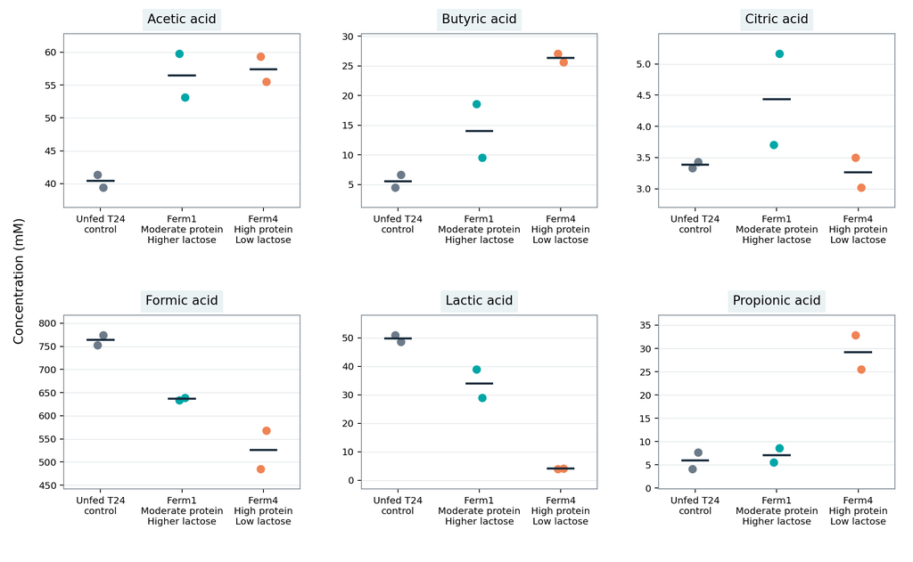

Figure 5: Organic-acid profiles of the unfed T24 control and selected 5% dairy fermentates. Points show individual fermentation wells; horizontal bars show condition means. Each panel has its own y-axis scale. Concentrations are in mM. Fermentate descriptors refer to ingredient composition.

Each facet uses its own y-axis scale so that differences within an acid remain visible when acids have very different measurement ranges. In the supplied CSV, formic acid values are much larger than the other acid measurements. With a shared scale, variation in the smaller measurements could be visually compressed.

Compare conditions **within a panel**. Equal-looking vertical gaps in different panels do not imply equal absolute differences. The small horizontal jitter separates overlapping points; it does not alter their measured values.

## 13.8 Duplicate differences versus differences between fermentates

For each acid and condition, define the **duplicate gap** as the absolute difference between R1 and R2. Define the **between-fermentate gap** as the absolute difference between the Ferm1 and Ferm4 means. Both gaps are expressed in mM for each acid.

A duplicate gap is not automatically technical variation: its meaning depends on what was replicated. Here it describes variation between the duplicate fermentation wells, not donor-to-donor variation or HPLC injection repeatability alone. Do not interpret a gap ratio as a test statistic or use it as a threshold for significance.

```r
# Summarise concentrations and replicate differences for each condition and acid.
acid_summary <- acids_long |>
  # Treat each condition–acid combination as a separate group.
  group_by(product, acid) |>
  # Reduce each group to a row containing the requested summary values.
  summarise(
    # Count non-missing values: is.na tests for missingness and ! reverses it.
    n_observed = sum(!is.na(value)),
    # Return a numeric missing value if all values are missing; otherwise average observed values.
    mean_value = if (all(is.na(value))) NA_real_ else mean(value, na.rm = TRUE),
    # When two values are present, subtract the minimum from the maximum; otherwise return NA.
    duplicate_gap = if (sum(!is.na(value)) == 2L) diff(range(value, na.rm = TRUE)) else NA_real_,
    # Remove grouping from the result so later operations use the whole table.
    .groups = "drop"
  )

# Calculate differences between the two fermentate means.
fermentate_gaps <- acid_summary |>
  # Keep the two fermentate conditions, excluding Control.
  filter(product %in% c("Ferm1", "Ferm4")) |>
  # Keep the columns needed to compare the two means.
  select(acid, product, mean_value) |>
  # Put the Ferm1 and Ferm4 means into separate columns for each acid.
  pivot_wider(names_from = product, values_from = mean_value) |>
  # Calculate the absolute difference between the fermentate means.
  mutate(between_gap = abs(Ferm4 - Ferm1))

# Combine within-condition gaps with between-fermentate gaps.
gap_comparison <- acid_summary |>
  # Match on acid, attaching the corresponding between-fermentate gap to each row.
  left_join(select(fermentate_gaps, acid, between_gap), by = "acid")

# Display the result as a formatted table in the reading guide.
knitr::kable(gap_comparison, digits = 3,
             caption = "Condition means and absolute gaps in mM; n_observed is a count.")
```

Condition means and absolute gaps in mM; n_observed is a count.

| product | acid | n_observed | mean_value | duplicate_gap | between_gap |
| --- | --- | --- | --- | --- | --- |
| Control | acetic | 2 | 40.415 | 1.964 | 0.972 |
| Control | butyric | 2 | 5.581 | 2.114 | 12.283 |
| Control | citric | 2 | 3.383 | 0.099 | 1.171 |
| Control | formic | 2 | 763.433 | 20.854 | 109.902 |
| Control | lactic | 2 | 49.760 | 2.292 | 29.944 |
| Control | propionic | 2 | 5.896 | 3.541 | 22.140 |
| Ferm1 | acetic | 2 | 56.430 | 6.621 | 0.972 |
| Ferm1 | butyric | 2 | 14.045 | 9.038 | 12.283 |
| Ferm1 | citric | 2 | 4.432 | 1.459 | 1.171 |
| Ferm1 | formic | 2 | 636.418 | 4.674 | 109.902 |
| Ferm1 | lactic | 2 | 33.994 | 9.941 | 29.944 |
| Ferm1 | propionic | 2 | 7.025 | 3.062 | 22.140 |
| Ferm4 | acetic | 2 | 57.401 | 3.860 | 0.972 |
| Ferm4 | butyric | 2 | 26.328 | 1.448 | 12.283 |
| Ferm4 | citric | 2 | 3.261 | 0.478 | 1.171 |
| Ferm4 | formic | 2 | 526.516 | 82.640 | 109.902 |
| Ferm4 | lactic | 2 | 4.050 | 0.151 | 29.944 |
| Ferm4 | propionic | 2 | 29.165 | 7.328 | 22.140 |

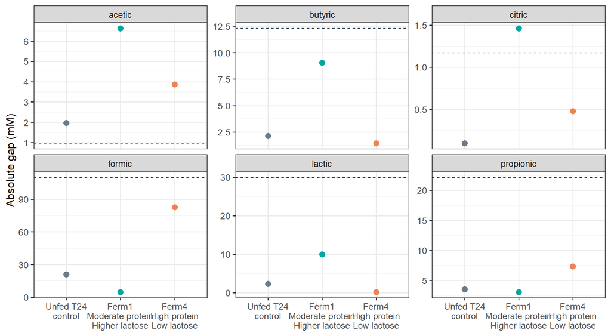

Figure 6: Within-condition duplicate gaps (points) compared with the absolute difference between the Ferm1 and Ferm4 means (dashed line). Each acid has its own y-axis scale. These gaps describe the observed data, not statistical significance.

```r
# Map condition to x and duplicate gap to y; colour points by condition.
ggplot(gap_comparison, aes(product, duplicate_gap, colour = product)) +
  # Add a horizontal reference line to each acid panel.
  geom_hline(
    # Use the table with one between-fermentate difference per acid.
    data = fermentate_gaps,
    # Place the horizontal line at that difference.
    aes(yintercept = between_gap),
    # Style the reference line as dark and dashed.
    linetype = "dashed", colour = "#172A3A"
  ) +
  # Show the duplicate gap for each condition as a point.
  geom_point(size = 3) +
  # Create one panel per acid in two rows; let each panel use its own y-axis range.
  facet_wrap(~acid, scales = "free_y", nrow = 2) +
  # Replace the x-axis category labels with the descriptive labels defined above.
  scale_x_discrete(labels = product_labels) +
  # Assign a consistent colour to each condition.
  scale_colour_manual(values = c(
    "Control" = "#6C7A89", "Ferm1" = "#00A6A6", "Ferm4" = "#EF8354"
  )) +
  # Label the gap axis and omit an unnecessary x-axis title.
  labs(x = NULL, y = "Absolute gap (mM)") +
  # Use a white-background theme with a base text size of 13.
  theme_bw(base_size = 13) +
  # Hide the redundant colour legend.
  theme(legend.position = "none")
```

For acetic acid, the Ferm1–Ferm4 mean gap is only about 0.972 mM, while the duplicate gaps for Ferm1 and Ferm4 are 6.621 and 3.860 mM. A small ordering of the means should therefore not be presented as a clear treatment separation. For butyric acid, the Ferm1–Ferm4 mean gap is 12.283 mM, compared with duplicate gaps of 9.038 mM for Ferm1 and 1.448 mM for Ferm4. A larger gap still does not, by itself, establish a statistically supported effect.

## 13.9 Interpretation exercise

Discuss the plot. When reading at home, write down one observation and one limitation before looking at the discussion prompts below.

1. Which acids appear to differ most among Control, Ferm1 and Ferm4?
2. Which product has the highest observed propionate and butyrate values?
3. Where do the two replicates appear least consistent?
4. What information do you need before interpreting the values?
5. Which conclusions would require more replication?

**Discussion prompts**

In the supplied data, both Ferm4 measurements have higher propionic and butyric acid values and lower lactic acid values than either Control measurement. The mean values for Ferm1 lie between Control and Ferm4 for these three acids. These are observed patterns, not evidence of a particular pathway or organism.

The two Ferm1 butyric-acid concentrations are 18.564 and 9.526 mM, a gap of 9.038 mM. The Ferm4 pair is closer: 27.052 and 25.604 mM, a gap of 1.448 mM. This is why it matters to display individual measurements alongside the mean.

Before making a biological interpretation, confirm the original product key, and inspect calibration and QC information. Remember that the duplicate wells share a pooled faecal inoculum. We know from the teaching subset description that Ferm1 and Ferm4 are the selected 5% conditions and Control is the unfed T24 reference. The data alone do not establish whether an observed difference arose from production, consumption or compounds already present in the fermentates.

# 14 Five take-home messages

1. **Metabolomics measures the small-molecule phenotype** and complements sequencing data.
2. **Targeted, semi-targeted and untargeted methods answer different questions.**
3. **Different platforms generate different signals but similar downstream tables.**
4. **Metadata, annotation and quality checks give the matrix its meaning.**
5. **A visible difference does not establish a statistically supported effect.**